# Brutus_Moise_MLHousePricesPrediction

```python
import markdown
import pandas as pd
import numpy as np
from sklearn.model_selection import train_test_split
import matplotlib.pyplot as plt
from sklearn.linear_model import LinearRegression
from sklearn.ensemble import RandomForestRegressor
from sklearn.metrics import mean_squared_error


#importing the data

df_train = pd.read_csv('C:/Users/moise/Downloads/House Prices Advanced Techniques/train.csv')
train = pd.DataFrame(df_train)

df_test = pd.read_csv('C:/Users/moise/Downloads/House Prices Advanced Techniques/test.csv')
test = pd.DataFrame(df_test)

print(train.shape)
print(df_test.shape)
```

```
(1460, 81)
(1459, 80)
```

The House Prices Advanced Regression Techniques Dataset is available on Kaggle for dowloanding. The dataset is broken into two files, 1. training data, and 2. testing data. The training data has 1460 observations and 80 features. The testing data has 1459 observations with 79 features. The testing data does not contain the target column. The feature types are a combination of int64, float64, and object types. The target variable is a continious variable.

```python
#Data exploration

train.head()
```

|  | Id | MSSubClass | MSZoning | LotFrontage | LotArea | Street | Alley | LotShape | LandContour | Utilities | ... | PoolArea | PoolQC | Fence | MiscFeature | MiscVal | MoSold | YrSold | SaleType | SaleCondition | SalePrice |
| --- | --- | --- | --- | --- | --- | --- | --- | --- | --- | --- | --- | --- | --- | --- | --- | --- | --- | --- | --- | --- | --- |
| 0 | 1 | 60 | RL | 65.0 | 8450 | Pave | NaN | Reg | Lvl | AllPub | ... | 0 | NaN | NaN | NaN | 0 | 2 | 2008 | WD | Normal | 208500 |
| 1 | 2 | 20 | RL | 80.0 | 9600 | Pave | NaN | Reg | Lvl | AllPub | ... | 0 | NaN | NaN | NaN | 0 | 5 | 2007 | WD | Normal | 181500 |
| 2 | 3 | 60 | RL | 68.0 | 11250 | Pave | NaN | IR1 | Lvl | AllPub | ... | 0 | NaN | NaN | NaN | 0 | 9 | 2008 | WD | Normal | 223500 |
| 3 | 4 | 70 | RL | 60.0 | 9550 | Pave | NaN | IR1 | Lvl | AllPub | ... | 0 | NaN | NaN | NaN | 0 | 2 | 2006 | WD | Abnorml | 140000 |
| 4 | 5 | 60 | RL | 84.0 | 14260 | Pave | NaN | IR1 | Lvl | AllPub | ... | 0 | NaN | NaN | NaN | 0 | 12 | 2008 | WD | Normal | 250000 |

5 rows × 81 columns

```python
test.head()
```

|  | Id | MSSubClass | MSZoning | LotFrontage | LotArea | Street | Alley | LotShape | LandContour | Utilities | ... | ScreenPorch | PoolArea | PoolQC | Fence | MiscFeature | MiscVal | MoSold | YrSold | SaleType | SaleCondition |
| --- | --- | --- | --- | --- | --- | --- | --- | --- | --- | --- | --- | --- | --- | --- | --- | --- | --- | --- | --- | --- | --- |
| 0 | 1461 | 20 | RH | 80.0 | 11622 | Pave | NaN | Reg | Lvl | AllPub | ... | 120 | 0 | NaN | MnPrv | NaN | 0 | 6 | 2010 | WD | Normal |
| 1 | 1462 | 20 | RL | 81.0 | 14267 | Pave | NaN | IR1 | Lvl | AllPub | ... | 0 | 0 | NaN | NaN | Gar2 | 12500 | 6 | 2010 | WD | Normal |
| 2 | 1463 | 60 | RL | 74.0 | 13830 | Pave | NaN | IR1 | Lvl | AllPub | ... | 0 | 0 | NaN | MnPrv | NaN | 0 | 3 | 2010 | WD | Normal |
| 3 | 1464 | 60 | RL | 78.0 | 9978 | Pave | NaN | IR1 | Lvl | AllPub | ... | 0 | 0 | NaN | NaN | NaN | 0 | 6 | 2010 | WD | Normal |
| 4 | 1465 | 120 | RL | 43.0 | 5005 | Pave | NaN | IR1 | HLS | AllPub | ... | 144 | 0 | NaN | NaN | NaN | 0 | 1 | 2010 | WD | Normal |

5 rows × 80 columns

```python
# training Data Exploration
train.info()
```

```
<class 'pandas.core.frame.DataFrame'>
RangeIndex: 1460 entries, 0 to 1459
Data columns (total 81 columns):
 #   Column         Non-Null Count  Dtype
---  ------         --------------  -----
 0   Id             1460 non-null   int64
 1   MSSubClass     1460 non-null   int64
 2   MSZoning       1460 non-null   object
 3   LotFrontage    1201 non-null   float64
 4   LotArea        1460 non-null   int64
 5   Street         1460 non-null   object
 6   Alley          91 non-null     object
 7   LotShape       1460 non-null   object
 8   LandContour    1460 non-null   object
 9   Utilities      1460 non-null   object
```

[output cut: 73 more lines]

```python
#Testing Data Exploration
test.info()
```

```
<class 'pandas.core.frame.DataFrame'>
RangeIndex: 1459 entries, 0 to 1458
Data columns (total 80 columns):
 #   Column         Non-Null Count  Dtype
---  ------         --------------  -----
 0   Id             1459 non-null   int64
 1   MSSubClass     1459 non-null   int64
 2   MSZoning       1455 non-null   object
 3   LotFrontage    1232 non-null   float64
 4   LotArea        1459 non-null   int64
 5   Street         1459 non-null   object
 6   Alley          107 non-null    object
 7   LotShape       1459 non-null   object
 8   LandContour    1459 non-null   object
 9   Utilities      1457 non-null   object
```

[output cut: 72 more lines]

```python
#Exploring the Target
train['SalePrice'].describe()
```

```
count      1460.000000
mean     180921.195890
std       79442.502883
min       34900.000000
25%      129975.000000
50%      163000.000000
75%      214000.000000
max      755000.000000
Name: SalePrice, dtype: float64
```

The mean Sale Price is \$180921. The min is about \\$35000. The max is \$755000.

```python
#Feature Selection using a correlation matrix
tcorr = train.corr()
tcorr.sort_values(["SalePrice"], ascending = False, inplace = True)
print(tcorr.SalePrice > 0.5)
```

```
SalePrice         True
OverallQual       True
GrLivArea         True
GarageCars        True
GarageArea        True
TotalBsmtSF       True
1stFlrSF          True
FullBath          True
TotRmsAbvGrd      True
YearBuilt         True
YearRemodAdd      True
GarageYrBlt      False
MasVnrArea       False
Fireplaces       False
BsmtFinSF1       False
LotFrontage      False
WoodDeckSF       False
2ndFlrSF         False
OpenPorchSF      False
HalfBath         False
LotArea          False
BsmtFullBath     False
BsmtUnfSF        False
BedroomAbvGr     False
ScreenPorch      False
PoolArea         False
MoSold           False
3SsnPorch        False
BsmtFinSF2       False
BsmtHalfBath     False
MiscVal          False
Id               False
LowQualFinSF     False
YrSold           False
OverallCond      False
MSSubClass       False
EnclosedPorch    False
KitchenAbvGr     False
Name: SalePrice, dtype: bool
```

According to the correlation Matrix the following features are mostly correlated to Sale Price. OverallQual, GrLivArea, GarageCars, GarageArea, TotalBsmtSF, 1stFlrSF. Our problem statement is create a regression model to model the features above 50% correlation threshold against Sale Price.

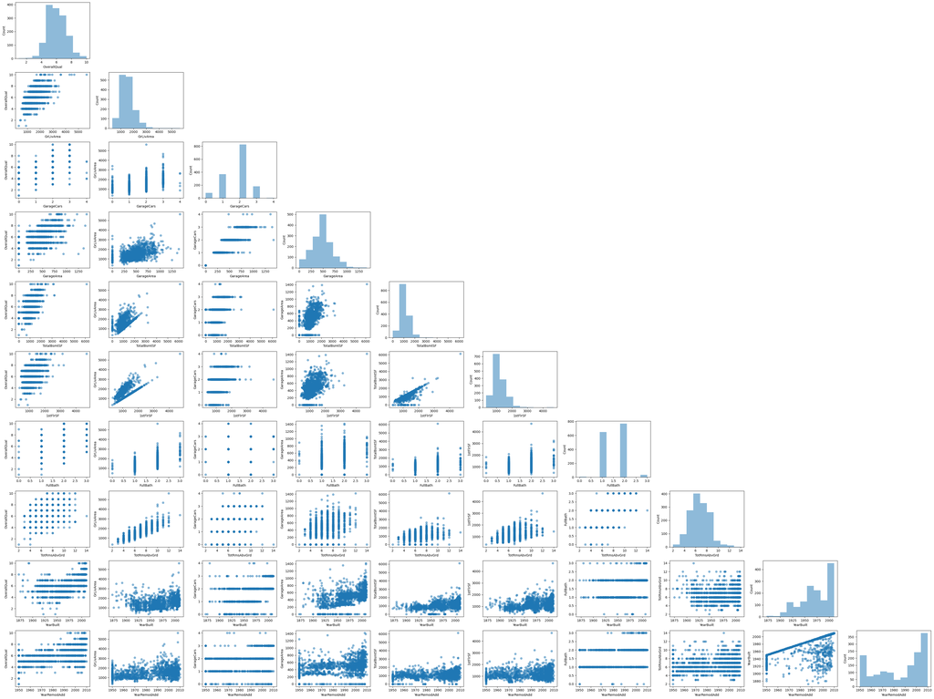

```python
#relationship between features
import matplotlib.pyplot as plt
from mlxtend.plotting import scatterplotmatrix
cols = ['OverallQual', 'GrLivArea', 'GarageCars','GarageArea', 'TotalBsmtSF', '1stFlrSF', 'FullBath', 'TotRmsAbvGrd', 'YearBuilt',
'YearRemodAdd']
scatterplotmatrix(train[cols].values, figsize=(40, 30), names=cols, alpha=0.5)
plt.tight_layout()
plt.show()
```

```python
#The target does not have any NA values
train['SalePrice'].isnull().sum()
train.drop_duplicates(inplace=True)
```

```python
#Selecting Data after feature selection
X = train[['OverallQual', 'GrLivArea', 'GarageCars','GarageArea', 'TotalBsmtSF', '1stFlrSF', 'FullBath', 'TotRmsAbvGrd', 'YearBuilt',
'YearRemodAdd']]
y = train['SalePrice']
```

```python
#Checking the features for missing values
X.isnull().sum()
```

```
OverallQual     0
GrLivArea       0
GarageCars      0
GarageArea      0
TotalBsmtSF     0
1stFlrSF        0
FullBath        0
TotRmsAbvGrd    0
YearBuilt       0
YearRemodAdd    0
dtype: int64
```

```python
#remove outliers

#replacing values > 0.75 quatertile with the mean
X['OverallQual'] = np.where(X['OverallQual'] > 6.099315, 5.747084, X['OverallQual'])
X['GrLivArea'] = np.where(X['GrLivArea'] > 1515.463699, 1342.785788, X['GrLivArea'])
X['GarageCars'] = np.where(X['GarageCars'] > 2, 1.767123, X['GarageCars'])
X['GarageArea'] = np.where(X['GarageArea'] > 576, 472.980137, X['GarageArea'])
X['TotalBsmtSF'] = np.where(X['TotalBsmtSF'] > 1298.250000, 1057.429452, X['TotalBsmtSF'])
X['1stFlrSF'] = np.where(X['1stFlrSF'] > 1391.250000, 1162.626712, X['1stFlrSF'])
X['FullBath'] = np.where(X['FullBath'] > 2, 1.565068, X['FullBath'])
X['TotRmsAbvGrd'] = np.where(X['TotRmsAbvGrd'] > 7, 6.517808, X['TotRmsAbvGrd'])
X['YearBuilt'] = np.where(X['YearBuilt'] > 2000, 1971.267808, X['YearBuilt'])
X['YearRemodAdd'] = np.where(X['YearRemodAdd'] > 2004, 1984.865753, X['YearRemodAdd'])
```

[output not shown]

```python
X.describe()
```

|  | OverallQual | GrLivArea | GarageCars | GarageArea | TotalBsmtSF | 1stFlrSF | FullBath | TotRmsAbvGrd | YearBuilt | YearRemodAdd |
| --- | --- | --- | --- | --- | --- | --- | --- | --- | --- | --- |
| count | 1460.000000 | 1460.000000 | 1460.000000 | 1460.000000 | 1460.000000 | 1460.000000 | 1460.000000 | 1460.000000 | 1460.000000 | 1460.000000 |
| mean | 5.418084 | 1239.569260 | 1.606633 | 407.136307 | 916.149144 | 1030.297089 | 1.532635 | 5.986669 | 1962.845536 | 1980.185419 |
| std | 0.682524 | 194.171039 | 0.571886 | 137.219435 | 241.477690 | 196.544511 | 0.505850 | 0.926214 | 23.568226 | 17.388509 |
| min | 1.000000 | 334.000000 | 0.000000 | 0.000000 | 0.000000 | 334.000000 | 0.000000 | 2.000000 | 1872.000000 | 1950.000000 |
| 25% | 5.000000 | 1129.500000 | 1.000000 | 334.500000 | 795.750000 | 882.000000 | 1.000000 | 5.000000 | 1954.000000 | 1967.000000 |
| 50% | 5.747084 | 1342.785788 | 2.000000 | 472.980137 | 991.500000 | 1087.000000 | 2.000000 | 6.000000 | 1971.267808 | 1984.865753 |
| 75% | 6.000000 | 1342.785788 | 2.000000 | 480.000000 | 1057.429452 | 1162.626712 | 2.000000 | 6.517808 | 1973.000000 | 1995.000000 |
| max | 6.000000 | 1513.000000 | 2.000000 | 576.000000 | 1298.000000 | 1391.000000 | 2.000000 | 7.000000 | 2000.000000 | 2004.000000 |

```
array([[<AxesSubplot:title={'center':'OverallQual'}>,
        <AxesSubplot:title={'center':'GrLivArea'}>,
        <AxesSubplot:title={'center':'GarageCars'}>],
       [<AxesSubplot:title={'center':'GarageArea'}>,
        <AxesSubplot:title={'center':'TotalBsmtSF'}>,
        <AxesSubplot:title={'center':'1stFlrSF'}>],
       [<AxesSubplot:title={'center':'FullBath'}>,
        <AxesSubplot:title={'center':'TotRmsAbvGrd'}>,
        <AxesSubplot:title={'center':'YearBuilt'}>],
       [<AxesSubplot:title={'center':'YearRemodAdd'}>, <AxesSubplot:>,
        <AxesSubplot:>]], dtype=object)
```

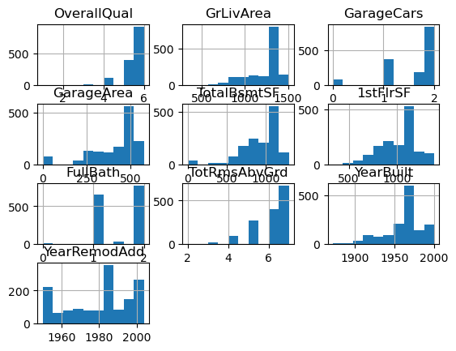

```python
X.hist()
```

```python
# Train Test Split Data
X_train, X_test, y_train, y_test = train_test_split(X,y,test_size=0.2,random_state=1)
```

I split the data into a 20/80 split because our data does not have a large number of observations. I wanted to capture a high amount of training data to combat underfitting. The 20/80 split ratio with 1,460 observations allows me to still have enough observations left over to test my model. I did not use the training data exclusively to train my data because I am also interested in the performance of the training set before applying it to the test set.

```python
#StandardScaler implementation
from sklearn.preprocessing import StandardScaler
mms = StandardScaler()
X_train = mms.fit_transform(X_train)
X_test = mms.transform(X_test)
```

I then implemented StandardScaler which effectively Standardize our features. I also experimented with MinMaxScaler but it yielded a lower R^2 score.

```
MSE: 4030520722.7063875
```

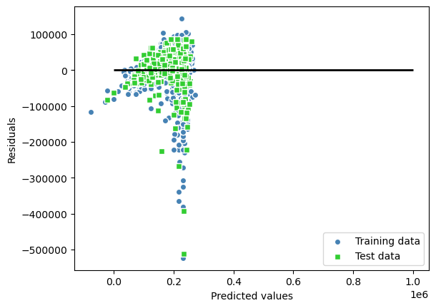

```
R^2 train: %.3f, test: %.3f 0.4605084869102253 0.4348636115125337
Intercept: 182208.342
```

```python
#Model
regressor = LinearRegression()
regressor.fit(X_train, y_train)

# Predict on the test set
y_pred = regressor.predict(X_test)

# Compute the mean squared error
from sklearn.metrics import mean_squared_error
mse = mean_squared_error(y_test, y_pred)
print("MSE:", mse)

#residuals graph
y_train_pred = regressor.predict(X_train)
y_test_pred = regressor.predict(X_test)

plt.scatter(y_train_pred, y_train_pred - y_train, c='steelblue', marker='o', edgecolor='white', label='Training data')
plt.scatter(y_test_pred, y_test_pred - y_test, c='limegreen', marker='s', edgecolor='white', label='Test data')
plt.xlabel('Predicted values')
plt.ylabel('Residuals')
plt.legend(loc='lower right')
plt.hlines(y=0, xmin=0, xmax=1000000, color='black', lw=2)
plt.show()

#Compute the r^2 term
from sklearn.metrics import r2_score
print('R^2 train: %.3f, test: %.3f', r2_score(y_train, y_train_pred), r2_score(y_test, y_test_pred))

print('Intercept: %.3f' % regressor.intercept_)
```

```
MSE train: 3286698918.028, test: 4030520722.706
```

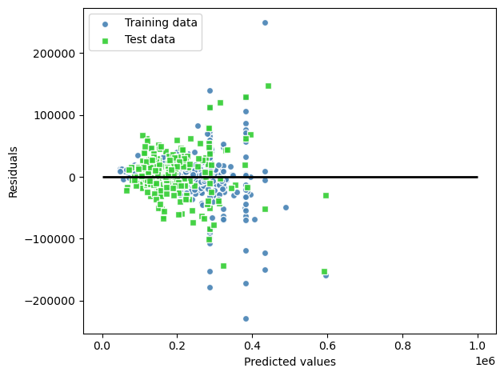

```
R^2 train: %.3f, test: %.3f 0.9084092889084732 0.8417574774710049
```

```python
#Random forest model
from sklearn.ensemble import RandomForestRegressor
forest = RandomForestRegressor(n_estimators=1000, criterion='mse', random_state=1)
forest.fit(X_train, y_train)
y_train_predm = forest.predict(X_train)
y_test_predm = forest.predict(X_test)
print('MSE train: %.3f, test: %.3f' % (mean_squared_error(y_train, y_train_pred), mean_squared_error(y_test, y_test_pred)))

plt.scatter(y_train_predm, y_train_predm - y_train, c='steelblue', edgecolor='white', marker='o', s=35, alpha=0.9, label='Training data')
plt.scatter(y_test_predm, y_test_predm - y_test, c='limegreen', edgecolor='white', marker='s', s=35, alpha=0.9, label='Test data')
plt.xlabel('Predicted values')
plt.ylabel('Residuals')
plt.legend(loc='upper left')
plt.hlines(y=0, xmin=0, xmax=1000000, color='black', lw=2)
plt.tight_layout()
plt.show()

#Compute the r^2 term
from sklearn.metrics import r2_score
print('R^2 train: %.3f, test: %.3f', r2_score(y_train, y_train_predm), r2_score(y_test, y_test_predm))
```